# Multiple Linear Regression

## ASSIGNMENT 3: Multiple Linear Regression

## Model Assumptions and Completely Randomized Designs (CRD)

*Deadline:April 7th , 2024, by 11:59 pm. Submit to Gradescope.ca*

© Thuntida Ngamkham 2022 Modified by Danika Lipman

**Problem 1**:

**From Assignment 1 Problem 1**, The amount of water used by the production facilities of a plant varies. Observations on water usage and other,possibility related,variables were collected for 249 months. The data is given in **water.csv file** The explanatory variables are

TEMP= average monthly temperature(degree celsius) sz PROD=amount of production(10cubic)

DAYS=number of operationing day in the month

HOUR=number of hours shut down for maintenance

The response variable is USAGE=monthly water usage(gallons/minute)

```r
waterdata = read.csv("https://raw.githubusercontent.com/DanikaLipman/DATA603/main/water.csv")
library(GGally)
library(mctest)
library(lmtest)
```

```r
model=lm(USAGE~PROD+TEMP+HOUR+DAYS, data=waterdata)
summary(model)
intermodel=lm(USAGE~(PROD+TEMP+HOUR)^2, data=waterdata)
summary(intermodel)
finalintermodel=lm(USAGE~PROD+TEMP+HOUR+PROD*TEMP+PROD*HOUR, data=waterdata)
summary(finalintermodel)
```

[output not shown]

From the outputs above, the best-fit model is

$$\begin{aligned}
\hat{USAGE}=\hat\beta_0PROD+\hat\beta_1TEMP+\hat\beta_2HOUR+\hat\beta_3PROD*TEMP+\hat\beta_4PROD*HOUR
\end{aligned}$$
Answer the following questions

1. Many researchers avoid the problems of multicollinearity by always omitting all but one of the ‘’redundant’’ variables from the model. By checking all pairwise combinations of predictors in scatterplots and using the VIF function, do you detect any high correlation (r>0.8) between predictors? Does there appear to be any problem with multicollinearity assumption?

```r
pairs(~USAGE+PROD+TEMP+HOUR+PROD*TEMP+PROD*HOUR, data=waterdata)

vif(model)
```

[output not shown]

**Answer to Q1a**

Our scatter plot of the combinations yielded no combinations with r>0.8.The VIF function agrees with this, showing no predictors over 2.0, suggesting there is no correlation between these predictors.

2. Conduct a test for heteroscedasticity (non constant variance) and plot a residual plot. Does there appear to be any problem with homoscedasticity assumption?

```r
plot(finalintermodel, which=1)
plot(finalintermodel, which=3)
bptest(finalintermodel)
```

[output not shown]

Note: make sure you use the model provided above for your analysis, and provide the correct null and alternative hypothesis, and p-value.

**Answer to Q1b**

The plot shows our residuals do not form a funnel shape. The scale location plot appears to be horizontal, with a slight curve on the left end. These findings suggests our model has equal variance. We can use a test to provide a more formal answer.

The Breusch-Pagan test is a mathematical way of detecting heteroscedasticity. The null hypothesis for our BP test is:

$H_0:$ Heteroscedasticity is not present $H_a:$ Heteroscedasticity is present

The p value for our BP test for our model is: p value = 0.8484, meaning we fail to reject the null hypothesis and can conclude heteroscedasticity is not present.

3. Provide a histogram for residuals, a normal Q-Q plot, and the Shapiro -Wilk test. Does there appear to be any problem with normality assumption? Be sure to state the hypotheses and report the p-value.

```r
hist(residuals(finalintermodel),main="Hist",breaks=20)
ggplot(waterdata, aes(sample=finalintermodel$residuals)) +
  stat_qq() +
  stat_qq_line()

shapiro.test(residuals(finalintermodel))
```

[output not shown]

**Answer to Q1c**

The histogram shows a spike directly in the center of the data, and slightly resembles a bell curve. The histogram suggests the data may be normal, but it is unlikely. The QQ plot shares the same conclusion. The plot shows the residuals form an S curve, suggesting that the data is not normal. To tests our assumptions based off these graphs, we conduct a Shaprio-Wilk test. For this test:

$H_0:$ The sample data are significantly normally distributed $H_a:$ The sample data are not significantly normally distributed

The p value of the Shapiro-Wilk test is <2.2x10^-16, meaning we reject our null hypothesis in favor of the alternate, and can conclude the data is not significantly normally distributed.

4. Plot the residuals vs predicted value $\hat{Y}$ plot, do you detect any patterns? Does there appear to be any problem with linearity assumption?

```r
ggplot(finalintermodel, aes(x=.fitted, y=.resid)) +
  geom_point() +geom_smooth()+
  geom_hline(yintercept = 0)
```

[output not shown]

**Answer to Q1d**

The residuals versus predicted (fitted) plot does not appear to have a pattern in the residuals. The residuals tend to lie equally across the horizontal line at 0. With this, we can say there does not appear to be any issue with the linearity assumption.

5. Do you detect any outliers by using Cook’s distance measure (using cooks.distance()>1 ) and Residual vs Leverage plot?

```r
plot(finalintermodel,which=5)
waterdata[cooks.distance(finalintermodel)>1.0,]
plot(finalintermodel,pch=18,col="red",which=c(4))
```

[output not shown]

**Answer to Q1e**

Our Residual vs Leverage plot did not have any outliers that lay outside of the 1.0 Cook’s distance threshold. To confirm this, we printed any values that have a cook distance of greater than 1.0. This returned nothing. We also plotted the data points with the highest Cook’s distance, and none of the distances exceeded 1.0, or even 0.5.

Therefore, we do not detect any outliers using a Cook’s distance of 1.0.

6. From part a-e, determine whether your model meets the assumptions of the analysis. If not, provide any suggestions to improve the model.

**Answer to Q1f**

1. Linearity Assumption. By plotting residuals versus fitted we can check if there is a pattern among the residuals. If there is a pattern, we can say our model does not meet the linearity assumption. Since there is no discernible pattern, we can say our model meets the linearity assumption.
2. Independence assumption
3. Equal variance assumption. Our model meets the equal variance assumption because the BP test fails to reject the null hypothesis, and the residuals plot does not contain a funnel shape.
4. Normality Assumption. Our model fails to meet the normality assumption. This is seen by the qqnorm plot having an “S” shape to it, and the Histogram shows a weak normal distribution. In addition, the Shapiro-Wilks rejects the null hypothesis, suggesting the data is not significantly normally distributed. A transformation to meet this assumption would be to use the Box-Cox transformation.
5. Multicolinearity. We checked the Variance Influence Factor of the predictors, and found no correlatin strength was greater than 2.
6. Outliers

**Problem 2:**

**From Assignment 2 Problem 4(c)**, variables CGDUR, MEM and SOCIALSU are consistently selected as the best predictors.

```r
KBI=read.csv("https://raw.githubusercontent.com/DanikaLipman/DATA603/main/KBI.csv", header = TRUE)
model=lm(BURDEN~(CGDUR+ MEM +SOCIALSU) , data=KBI)
summary(model)
```

```
Call:
lm(formula = BURDEN ~ (CGDUR + MEM + SOCIALSU), data = KBI)

Residuals:
    Min      1Q  Median      3Q     Max
-32.672  -9.977   0.367   7.774  31.523

Coefficients:
             Estimate Std. Error t value Pr(>|t|)
(Intercept) 115.53922   12.36816   9.342 3.86e-15 ***
CGDUR         0.12168    0.06486   1.876   0.0637 .
MEM           0.56612    0.10232   5.533 2.73e-07 ***
SOCIALSU     -0.49237    0.08930  -5.514 2.96e-07 ***
---
Signif. codes:  0 ‘***’ 0.001 ‘**’ 0.01 ‘*’ 0.05 ‘.’ 0.1 ‘ ’ 1

Residual standard error: 15.25 on 96 degrees of freedom
Multiple R-squared:  0.4397,    Adjusted R-squared:  0.4222
F-statistic: 25.12 on 3 and 96 DF,  p-value: 4.433e-12
```

```r
interactionmodel=lm(BURDEN~(CGDUR+ MEM +SOCIALSU)^2 , data=KBI)
summary(interactionmodel)
```

```
Call:
lm(formula = BURDEN ~ (CGDUR + MEM + SOCIALSU)^2, data = KBI)

Residuals:
    Min      1Q  Median      3Q     Max
-32.256  -9.544   0.419   7.832  35.226

Coefficients:
                Estimate Std. Error t value Pr(>|t|)
(Intercept)    98.094196  27.929492   3.512 0.000688 ***
CGDUR           0.350722   0.525520   0.667 0.506181
MEM             0.869719   0.790027   1.101 0.273793
SOCIALSU       -0.341339   0.210830  -1.619 0.108828
CGDUR:MEM       0.003782   0.004228   0.894 0.373411
CGDUR:SOCIALSU -0.002564   0.004042  -0.634 0.527485
MEM:SOCIALSU   -0.002998   0.006087  -0.492 0.623553
---
Signif. codes:  0 ‘***’ 0.001 ‘**’ 0.01 ‘*’ 0.05 ‘.’ 0.1 ‘ ’ 1

Residual standard error: 15.4 on 93 degrees of freedom
Multiple R-squared:  0.4459,    Adjusted R-squared:  0.4102
F-statistic: 12.47 on 6 and 93 DF,  p-value: 2.879e-10
```

From the output above, none of interaction terms are significant. Therefore,the final model for prediction is
$$\widehat{BURDEN}= 115.539 + 0.566MEM - 0.49237SOCIALSU + 0.121CGDUR$$

Use the final model above to answer the following questions

1. Check normality, homoscedasticity, and linearity assumptions.

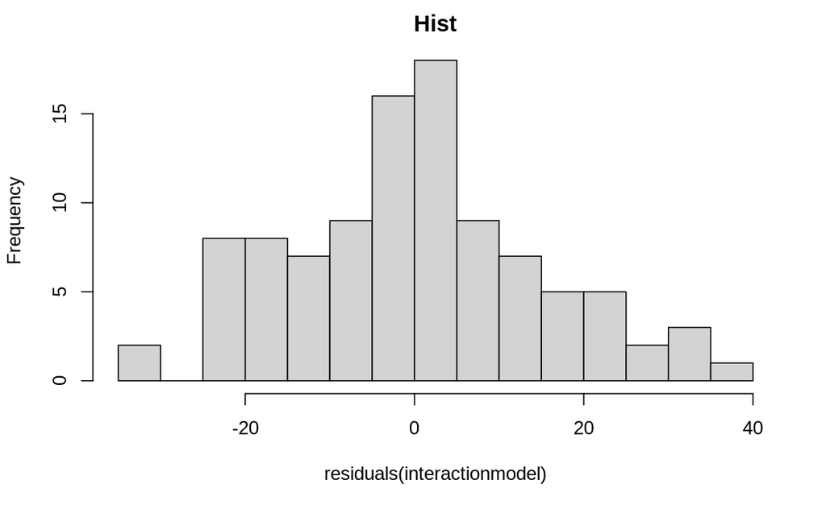

```r
#Normality
hist(residuals(interactionmodel),main="Hist",breaks=20)
```

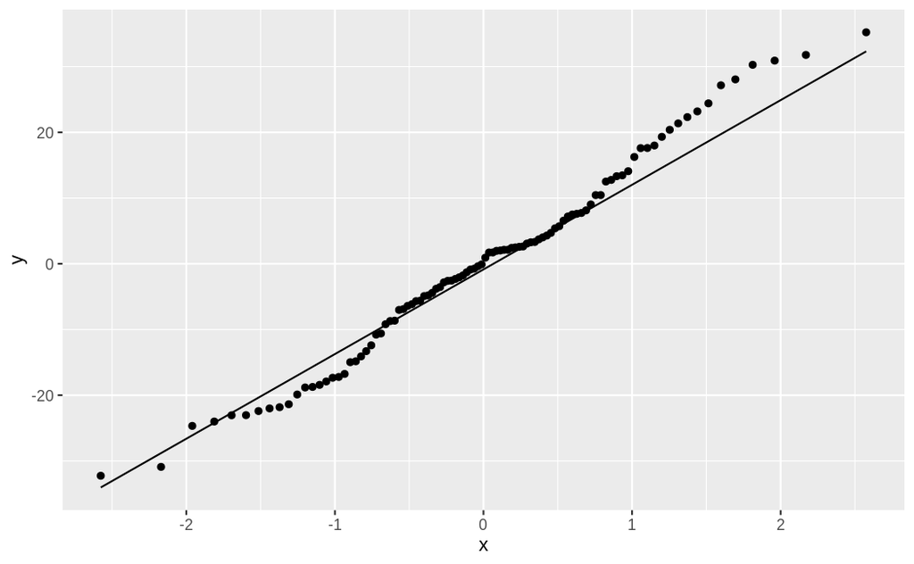

```r
ggplot(KBI, aes(sample=interactionmodel$residuals)) +
  stat_qq() +
  stat_qq_line()
```

```r
shapiro.test(residuals(interactionmodel))
```

```
    Shapiro-Wilk normality test

data:  residuals(interactionmodel)
W = 0.98536, p-value = 0.337
```

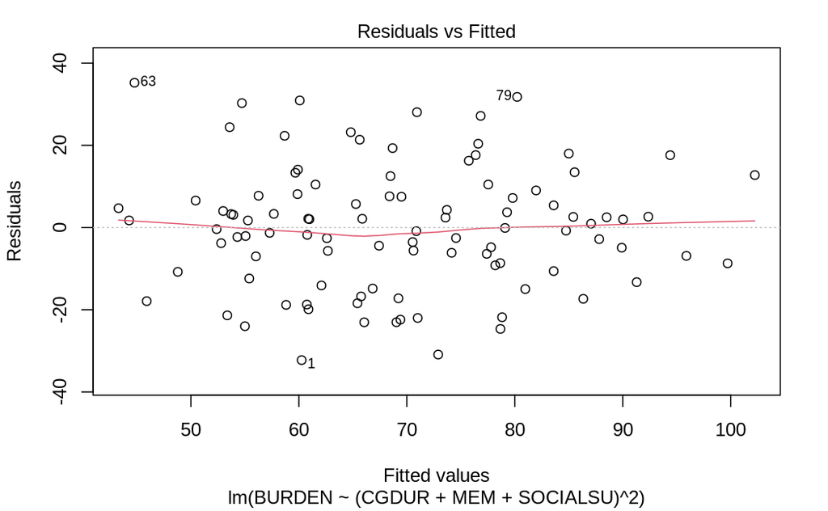

```r
#Homoscedascity
plot(interactionmodel, which=1)
```

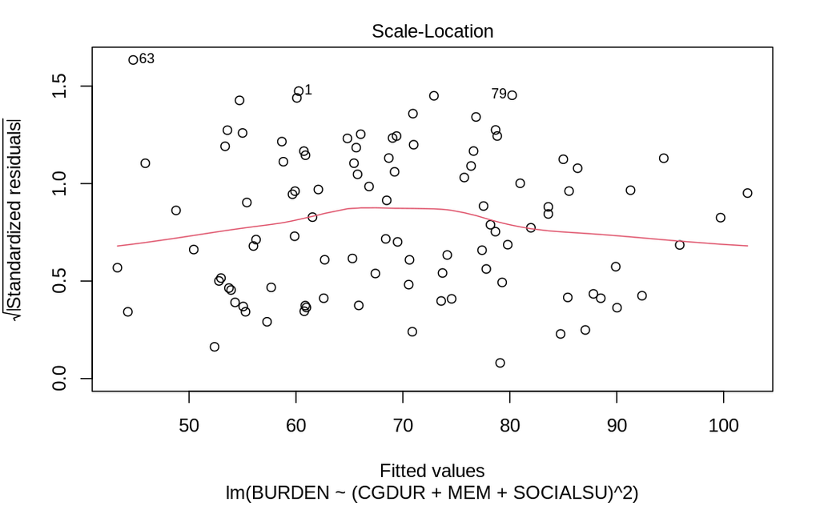

```r
plot(interactionmodel, which=3)
```

```r
bptest(interactionmodel)
```

```
    studentized Breusch-Pagan test

data:  interactionmodel
BP = 6.9915, df = 6, p-value = 0.3216
```

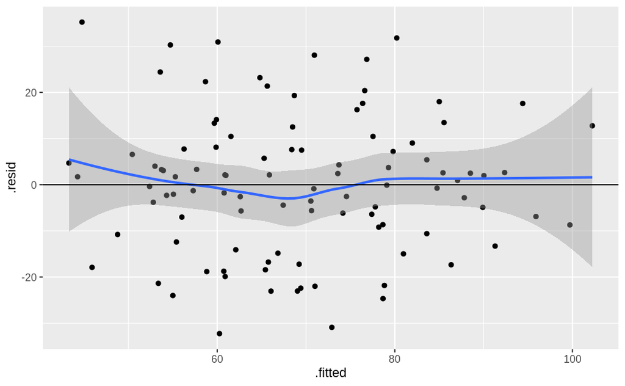

```r
#Linearity
ggplot(interactionmodel, aes(x=.fitted, y=.resid)) +
  geom_point() +geom_smooth()+
  geom_hline(yintercept = 0)
```

**Answer to Q2a**

1.Normality

3.Linearity

To test our linearity assumptions we created a plot of our fitted values versus residuals. We did not see a discernible pattern here, meaning that we can say we satisfy the linearity assumption.

2. Do you detect any outliers by using leverage values greater that $\frac{3p}{n}$? If yes, create a new dataset that removes these outliers.

((c) Fit the model

$$\widehat{BURDEN}= \hat{\beta_0} + \hat{\beta_1}MEM +
\hat{\beta_2}SOCIALSU + \hat{\beta_3}CGDUR$$

again using the new dataset created in part (b). Compare the results with the model the final model from **From Assignment 2 Problem 4(c)** . Do you notice any difference in the results of this model using two different data sets? Compare RSE, significance, and adjusted $R^2$.

**Problem 3:**

The average butterfat content of milk from dairy cows was recorded for each of five breeds of cattle. Random samples of ten mature (older than 4 years) and ten 2-year olds were taken.

The data are saved in the file named **butterfat.csv**

1. Plot box-plots using the R command boxplot( ) or ggplot( ) as in DATA 602 for the butterfat against breed, and also against age. Compare the variability/ interquartile range ($Q_3-Q_1$) among breed’s levels and among age’s levels
2. Fit a linear model using Age and Breed as independent variables. Would you keep Age in your model?
3. Perform a diagnostics (normality and constant variance assumptions, Normal Q-Q plot) analysis for your model fitted in part (b). What is your conclusion? State all correct hypotheses and p-values for statistical tests.
4. Fit an appropriate linear regression model by identifying a suitable transformation of your response variable [Box-Cox Transformation]. Compare the results with the model fitted in part c.
5. Perform a diagnostics analysis for the model fitted in part (d)

**Problem 4:**

Numerous factors contribute to the smooth running of an electric motor (“Increasing Market Share Through Improved Product and Process Design: An Experimental Approach,” Quality Engineering,1991: 361-369). In particular, it is desirable to keep motor noise and vibration to a minimum. To study the effect that the brand of bearing has on motor vibration, five different motor bearing brands were examined by installing each type of bearing on different random samples of six motors. The amount of motor vibration (measured in microns) was recorded when each of the 30 motors was running. The data for this study is given in the data file **vibration.csv**

1. What are the response variable and an experimental unit?
2. What is the treatment and how many treatment levels of this experiment?
3. Test and conclude if the average amount of motor vibrations are different at significance level =0.05. Be sure to include your hypothesis and p-value.
4. Construct the Anova table for the test.
5. Construct the boxplots for all levels. Do you detect any influential outliers?
6. Test all possible pariwise t tests (both Unadjusted and adjusted P-value), Tukey HSD , Newman-Keuls, and Scheffe Test. Compare all outputs and report your results.
7. Check all basic assumptions for CRD using plots and hypothesis tests and report your result. If some assumptions are not met, what would you proceed?